# Relationship of Variates

2018-08-09

$\renewcommand{\tr}[1]{{#1}^{\mkern-1.5mu\mathsf{T}}}$ $\renewcommand{\ve}[1]{\mathbf{#1}}$ $\renewcommand{\sv}[1]{\boldsymbol{#1}}$ $\renewcommand{\pop}[1]{\mathcal{#1}}$ $\renewcommand{\samp}[1]{\mathcal{#1}}$ $\renewcommand{\imply}{\Longrightarrow}$ $\renewcommand{\given}{~\vert~}$ $\renewcommand{\suchthat}{~:~}$ $\renewcommand{\widebar}[1]{\overline{#1}}$ $\renewcommand{\wig}[1]{\tilde{#1}}$ $\renewcommand{\bigwig}[1]{\widetilde{#1}}$ $\renewcommand{\field}[1]{\mathbb{#1}}$ $\renewcommand{\Reals}{\field{R}}$ $\renewcommand{\abs}[1]{\left\lvert ~{#1} ~\right\rvert}$ $\renewcommand{\size}[1]{\left\lvert {#1} \right\rvert}$ $\renewcommand{\tr}[1]{{#1}^{\mkern-1.5mu\mathsf{T}}}$ $\renewcommand{\norm}[1]{\left|\left|{#1}\right|\right|}$ $\renewcommand{\intersect}{\cap}$ $\renewcommand{\union}{\cup}$

```r
library(eikosograms)
```

# Dependence/Independence

As with continuous data, interest lies in assessing whether the values of catergorical variates might have been generated independently.

Independence occurs between X and Y if, and only if,
$$Pr(Y = y | X = x) = Pr(Y = y)$$
Or, equivalently,
$$Pr(X = x | Y = y) = Pr(X = x)$$
for all possible values x and y. This condition shows up in an eikosogram when the eikosogram is flat.

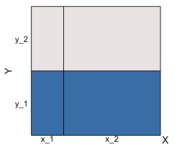

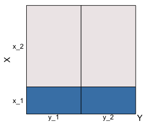

It is also applicable when each variate has more than two values.

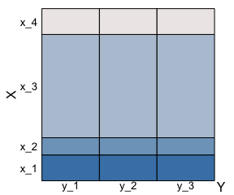

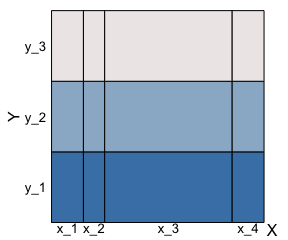

# Other Relationships

Dependence between a pair of ordered categorical variates can be seen in an eikosogram.

Suppose we have two binary categorical variates X and Y that each take values of either “yes” or “no. If the value is”yes“, then the event associated with that variate occurred, if”no" then it did not.

Many important relationships between two binary variates can be easily detected when displayed as eikosograms. These include:  
- independence  
- coincident events  
- mutually exclusive events  
- positive association  
- negative association

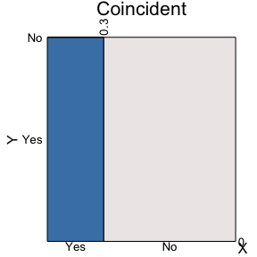

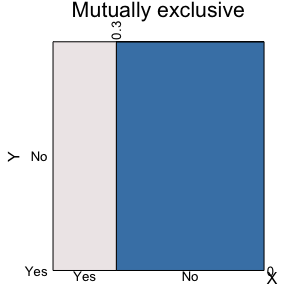

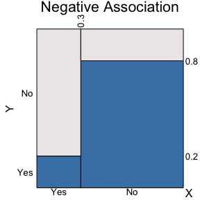

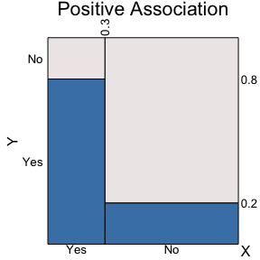

Consider the blue area as a liquid, and it flows from right to the left graduately in the transition. You can see the visual transition as the dependence changes.

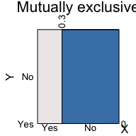

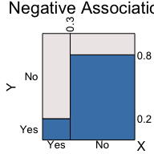

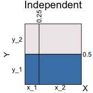

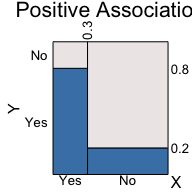

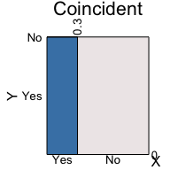

## Conditional Independence

When the data has multiple dimensions, the variates can be conditional independent given other variates. The key is to look for flat regions under some graph. For example, the following eikosograms show the joint distribution of X, Y, and Z. X and Y are conditionally independent given Z:

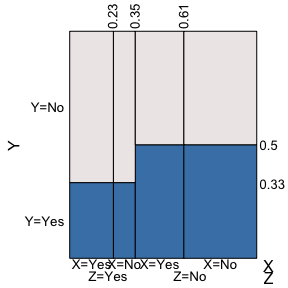

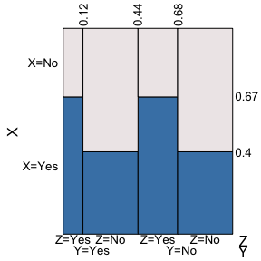

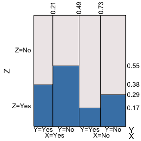

That is, $X \perp Y | Z$.